# Weather-related Disasters in Numbers: A Case Study in The US

Andres Camilo Zuñiga Gonzalez

18/5/2020

Weather events are a threat that humankind has had to face from the beginning; however, with an increasing population and built area all over the world, the consequences of natural disasters tend to be greater. In The US, these events have caused several damages in terms of loss of properties or even worse, the loss of human lives. In the following report, you will find a brief summary of the cost of natural disasters in The US, measured in fatalities, injuries and property damage. This is by no means a comprehensive analysis of the consequences of weather-related events, although it is an exploratory view of how these affect the country in several aspects. In particular, this analysis focuses on the different types of events that have ocurred between 1950 and 2011. Furthermore, in this analysis the focus is on those types of events that have had ocurred several times in that timespan and have had significant effects in terms of deaths, injured people, and millions of dollars lost in property and crop damage.

First, we load the necessary packages

```r
library(data.table) #Reading data
library(dplyr) #handling data
library(plyr) #Mapping values in dataFrames
library(ggplot2) #Plotting system
```

# Data Processing

As a first step in the overall analysis, the data must be downloaded. Unzipping is not necessary if you have installed the `R.utils` package. Make sure it is installed.

```r
setwd('./Reproducible_Research/Week4')
download.file('https://d396qusza40orc.cloudfront.net/repdata%2Fdata%2FStormData.csv.bz2', destfile = 'stormData.csv.bz2')
```

```r
storm <- fread('stormData.csv.bz2', na.strings = c('NA'), select = c('EVTYPE', 'FATALITIES', 'INJURIES', 'PROPDMG', 'PROPDMGEXP', "CROPDMG", "CROPDMGEXP"), colClasses = list(factor = c('EVTYPE')))

storm$PROPDMGEXP <- as.numeric(mapvalues(tolower(storm$PROPDMGEXP), from = c('', '?', '+', '-', '0', '1', '2', '3', '4', '5', '6', '7', '8', 'h', 'k', 'm', 'b'), to = c(1, 0, 1, 1, 1, 0, 10^2, 10^3, 10^4, 10^5, 10^6, 10^7, 10^8, 10^2, 10^3, 10^6, 10^9)))
storm$TOTALPROPDMG <- storm$PROPDMG * storm$PROPDMGEXP

storm$CROPDMGEXP <- as.numeric(mapvalues(tolower(storm$CROPDMGEXP), from = c('', '?', '0', '2', 'k', 'm', 'b'), to = c(1, 0, 1, 10^2, 10^3, 10^6, 10^9)))
storm$TOTALCROPDMG <- storm$CROPDMG * storm$CROPDMGEXP
```

The mapped values are:

- $?, 1 = 0$
- $'', +, -, 0 = 10^{0} = 1$
- $2, 3, 4, 5, 6, 7, 8 = 10^{n}$, where $n$ corresponds to each number
- $h, k, m, b = 10^{2}, 10^{3}, 10^{6}, 10^{9}$, according to each prefix: **h**ecto, **k**ilo, **m**ega and **b**illion

For the analysis of deadliest and costliest types of events, the data must be grouped according to EVTYPE, as shown below:

```r
byEventType <- storm %>%
    group_by(EVTYPE) %>%
    dplyr::summarise(TotalEvents = n(), #Number of Events
              TotalFatalities = sum(FATALITIES), #Total number of fatalities
              AvgFatalities = round(mean(FATALITIES, na.rm = T), 2), #Mean number of fatalities
              TotalInjuries = sum(INJURIES), #Total number of injuries
              AvgInjuries = round(mean(INJURIES, na.rm = T), 2), #Mean number of injuries
              TotalPropertyDamage = sum(TOTALPROPDMG), #Total property damage cost
              AvgPropertyDamage = round(mean(TOTALPROPDMG, na.rm = T), 2), #Mean property damage cost
              TotalCropDamage = sum(TOTALCROPDMG), #Total property damage cost
              AvgCropDamage = round(mean(TOTALCROPDMG, na.rm = T), 2)) #Mean crop damage cost
```

# Results

```r
events <- byEventType[byEventType$TotalEvents > 1, ]
events <- events[events$TotalInjuries > 0, ]
events <- events[events$TotalFatalities > 0, ]
events <- events[events$TotalPropertyDamage > 0, ]
events <- events[events$TotalCropDamage > 0, ]
```

## Fatalities

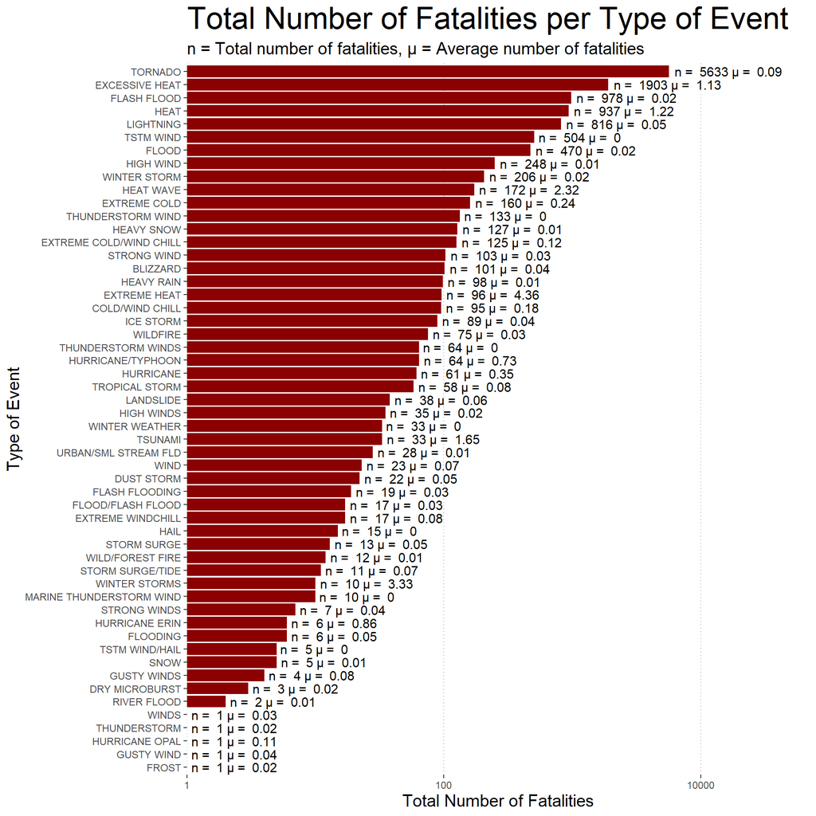

```r
ggplot(events) +
    geom_bar(stat = 'identity', aes(x = TotalFatalities, y = reorder(EVTYPE, TotalFatalities)), fill = 'red4') +
    geom_text(aes(label = paste('n = ', TotalFatalities, 'μ = ', AvgFatalities), x = TotalFatalities , y = EVTYPE), position = position_dodge(0.9), hjust = -0.05, size = 4) +
    scale_x_log10(limits = c(1, 70000), expand = c(0, 0)) +
    labs(x = 'Total Number of Fatalities', y = 'Type of Event', title = 'Total Number of Fatalities per Type of Event', subtitle = 'n = Total number of fatalities, μ = Average number of fatalities') +
    theme(plot.title = element_text(size = 27), plot.subtitle = element_text(size = 15), axis.title = element_text(size = 15), axis.text = element_text(size = 9), panel.grid.major.y = element_blank(), panel.background = element_blank(), panel.grid.major.x = element_line(colour = 'grey', linetype = 3))
```

## Injuries

Just as in the fatalities, with injuries the number of times an event has happened is a critical aspect. Below there is a chart of the average number of injuries per type of event. Notice the scale of the x axis is squared root.

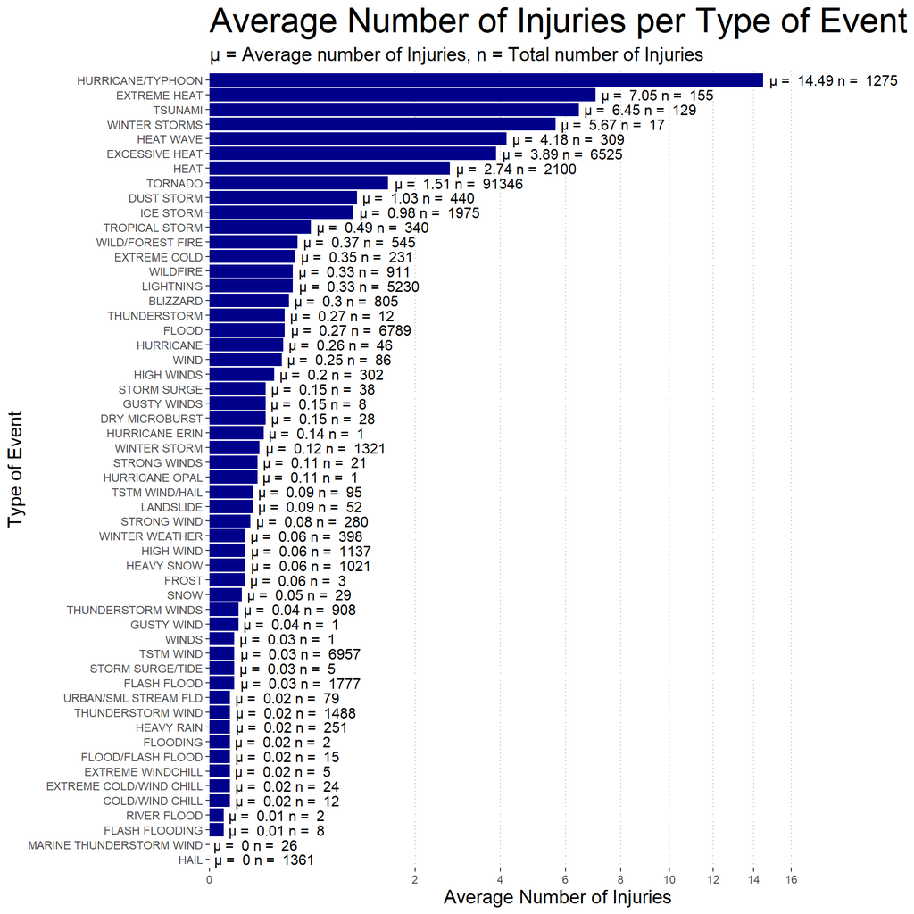

```r
ggplot(events) +
    geom_bar(stat = 'identity', aes(x = AvgInjuries, y = reorder(EVTYPE, AvgInjuries)), fill = 'blue4') +
    geom_text(aes(label = paste('μ = ', AvgInjuries, 'n = ', TotalInjuries), x = AvgInjuries , y = EVTYPE), position = position_dodge(0.9), hjust = -0.05, size = 4) +
    scale_x_sqrt(limits = c(0, 23), expand = c(0,0), breaks = seq(0, 16, 2)) +
    labs(x = 'Average Number of Injuries', y = 'Type of Event', title = 'Average Number of Injuries per Type of Event', subtitle = 'μ = Average number of Injuries, n = Total number of Injuries') +
    theme(plot.title = element_text(size = 27), plot.subtitle = element_text(size = 15), axis.title = element_text(size = 15), axis.text = element_text(size = 9), panel.grid.major.y = element_blank(), panel.background = element_blank(), panel.grid.major.x = element_line(colour = 'grey', linetype = 3))
```

## Property Damage

For the analysis of property damage, it is a bit trickier. First, I created anew variable with the average property damage per type in millions, so that it is easier to build the barplot. Then the syntaxis of the plot is pretty much the same as the others. Notice the scale is logarithmic.

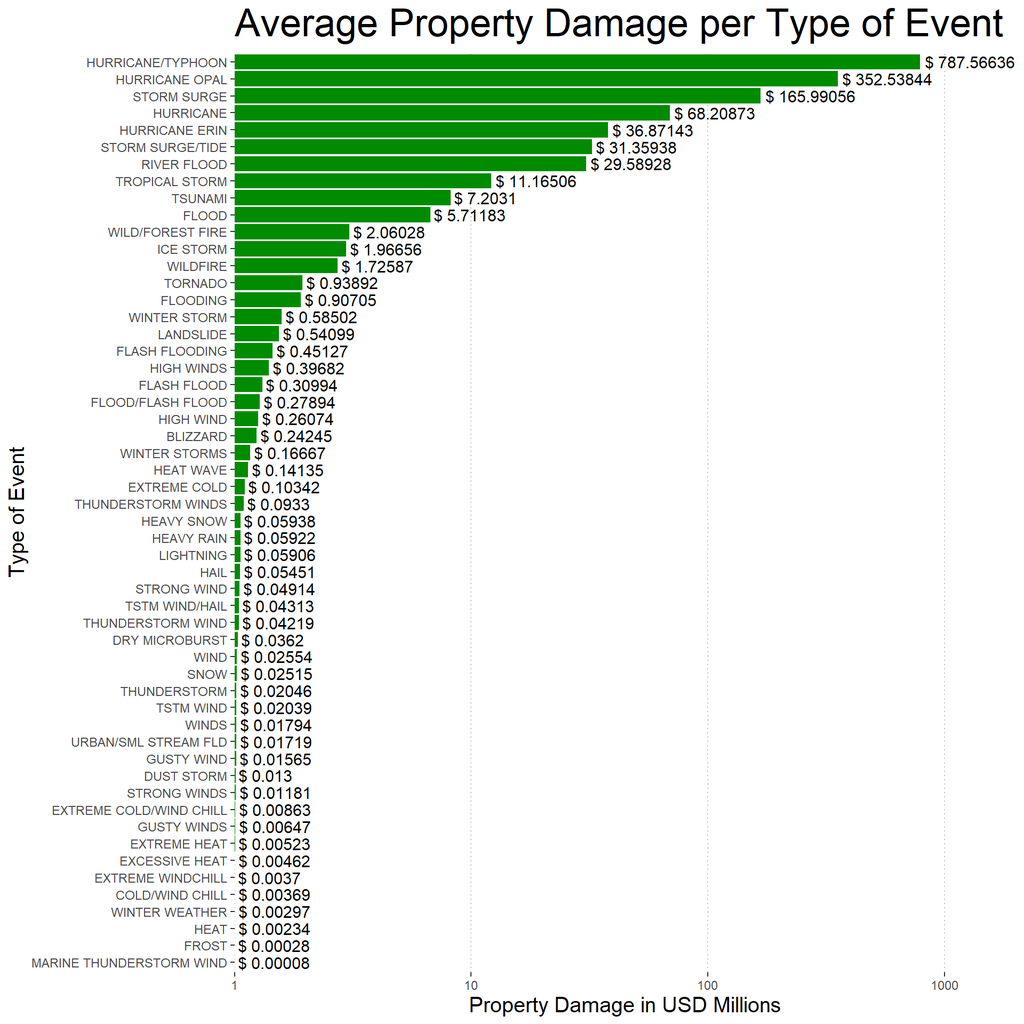

```r
events$AvgPropertyDamageMill <- round(events$AvgPropertyDamage / 10 ^ 6, 5)

ggplot(events) +
    geom_bar(stat = 'identity', aes(x = AvgPropertyDamageMill + 1, y = reorder(EVTYPE, AvgPropertyDamage)), fill = 'green4') +
    geom_text(aes(label = paste('$', AvgPropertyDamageMill), x = AvgPropertyDamageMill + 1, y = EVTYPE), position = position_dodge(0.9), hjust = -0.05, size = 4) +
    scale_x_log10(limits = c(1, 2000), expand = c(0, 0)) +
    labs(x = 'Property Damage in USD Millions', y = 'Type of Event', title = 'Average Property Damage per Type of Event') +
    theme(plot.title = element_text(size = 27), plot.subtitle = element_text(size = 15), axis.title = element_text(size = 15), axis.text = element_text(size = 9), panel.grid.major.y = element_blank(), panel.background = element_blank(), panel.grid.major.x = element_line(colour = 'grey', linetype = 3))
```